# Анализ сетей книг

Лунев Степан, silunev

## Загрузка библиотек и данных

Для начала загрузим все необходимые данные, а также преобразуем все переменные в нужные форматы.

**Главная задача данной работы** - исследовать структуру взаимосвязей между комиксами на основе сети из 777 популярных комиксов, где связь между книгами это похожесь по оценкам пользователей (если книги похожи по пользовательским оценкам, то между ними в графе есть связь).

## Исследовательские вопросы

1. Какие комиксы являются самыми популярными, а какие наоборот?
2. Есть ли взаимосвязь между оценками пользователей работ одного и того же (первого) автора?
3. Есть ли какие-то жанры, у которых присутствует склонность к получению похожих оценок?

Для начала выведем самые популярные комиксы из предложенных данных. Логично будет считать популярность комикса по количеству оценок, ведь чем больше оценок - тем больше просмотров, а значит популярнее комикс.

[figure not shown]

А теперь наоборот, самые непопулярные среди читателей комиксы.

[figure not shown]

Таким образом, самый популярный среди пользователей Goodreads комикс - “Watchmen”, когда самый непопулярный и малооцененный - “Batgirl.Volume 1:Beyound Burnside”.

Для дальнейших ответов на исследовательские вопросы, нам необходимо добавить к узлам сети несколько атрибутов. Для обозначения автора мы берем колонку **authors.0.author_id**, а для обозначения жанра мы берем колонку **popular_shelves.1.name**.

А теперь построим оба графика для ответов на данные вопросы:

[interactive chart not shown]

Попереключаясь на графике между авторами, мы видим, что связи между комиксами (примерно равные оценки) формируются без какой-то конкретной привязки к автору. Для того, чтобы лишний раз в этом убедиться, нам надо рассчитать коэффициент ассортативнности. Он поможет подтвердить данный вывод.

```
## [1] 0.003246878
```

Коэффициент ассортативности равен 0.003, что приближенно к 0, а значит, что представленный вывод выше подтвержден. Следовательно, читатели могут по-разному оценивать комиксы одного и того же автора.

[interactive chart not shown]

Попрыгая на графике между жанрами, мы узнаем, что никаких сообществ книг с похожими оценками нет. Даже невзирая на одинаковый жанр, комиксы разбросаны в пространстве. Чтобы определить склонность образования связей по похожим жанрам, мы как и для прошлого графика нам рассчитаем коэффициент ассортативности. Он поможет нам окончательно убедиться в наших выводах.

```
## [1] 0.0009880876
```

Полученный коэффициент ассортативности равен 0.0009, что довольно таки близко к 0, и говорит нам о факте связи между комиксами без привязки к какому-то конкретному жанру. Следовательно, можно окончательно сказать, что комиксы склонны к получению похожих оценок вне зависимости от жанра.

## Выявление значимых вершин

Выявление значимых вершин будет происходить с помощью метрик центральности. В данной работе будут использованы две метрики: *degree* и *betweenness*

**Использованные меры центральности:**

Для того, чтобы определить вершины с наибольшим количеством связей, мы используем метрику *degree*, после чего выведем 10 первых значений.

```
##          degree
## 282356      109
## 24819813     92
## 59980        90
## 25102        90
## 472331       89
## 21998105     87
## 23732096     87
## 29775583     85
## 107172       79
## 25103        77
```

Затем, с помощью метрики *betweenness* мы определим “вершины-мосты” нашей сети, которые соединяют наибольшее количество сообществ. Также обозначим 10 первых значений.

```
##          betweenness
## 282356     24992.547
## 59980      18306.750
## 4645370    15667.467
## 25102      15313.505
## 7395327    13979.781
## 23017947   11060.453
## 472331     10422.179
## 6120349     9988.091
## 24819813    9615.790
## 22426       9227.898
```

#### Визуализация

Теперь же визуализируем сеть с дифференциацией ее вершин по цвету и размеру согласно нашим метрикам:

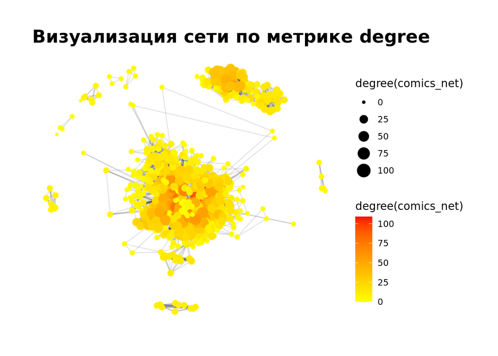

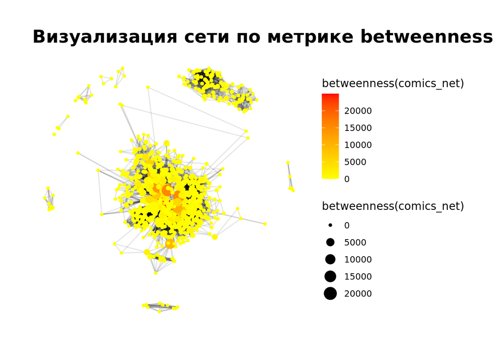

#### Выводы

Таким образом, мы определили ТОП-10 вершин согласно метрикам *degree* и *betweenness*. На обеих графиках можно увидеть крупные скопления вершин,а также увидеть, что в центре этих скоплений и находятся вершины с самыми высокими значениями *degree* и *betweenness*, что может нам говорить о том, что скопления могли образоваться именно благодаря им в первую очередь. В добавок к этому, если еще раз посмотреть на ТОП-10 значений, то мы можем увидеть одинаковые вершины в обеих метриках, например, 282356, 59980, 25102.

## Выявление групп книг

В этом пункте мы выделим сообщества книг, которые схожи по своим оценкам.

**Использованные меры выделения сообществ:**

Для выявления сообществ в данной работе будет использован метод *fast-greedy*

#### Визуализация

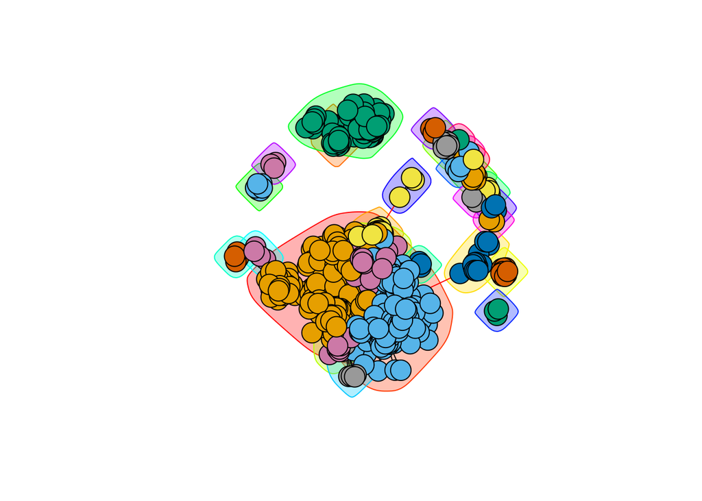

#### Выводы

Результатом визуализации можно выделить, что получилось довольно много сообществ, если быть точным - 28 штук. Это говорит нам о множестве представленных различий между представленными произведениями в данном датасете.

## Общие выводы

Подводя итоги данной работы, можно выделить следующие выводы:

1. Самый популярный комикс - “Watchmen”, когда самый непопулярный - “Batgirl.Volume 1:Beyound Burnside”.
2. Читатели могут по-разному оценивать комиксы одного и того же автора, связи между комиксами формируются без какой-то конкретной привязки к авторую.
3. Комиксы склонны к получению похожих оценок вне зависимости от жанра, а значит жанры, у которых присутствует склонность к получению похожих оценок - отсутствуют.
4. У произведений в представленном датасете множество различий, из-за чего было выделено большое количество сообществ, а именно - 28 штук.